# On the Design, Implementation and Use of Laziness in R

# 1 Overview

## 1.1 Functions and Calls

We observe 58 M calls to 2.3 K functions. Out of these, 4 M calls exit early due to longjump (exception handling or non-local promise returns). Of the remaining 54 M (93.1%) calls to 2.1 K (91.2%) functions, 14 M (26.0%) calls are made to 114 builtin functions, 31.8 M (58.8%) calls are made to 32 special functions and 8.2 M (15.2%) calls are made to 2 K R functions. Of these calls to R functions 192.7 K (2%) calls are made to 190 ( 9.7%) S3 methods, 699 (0.009%) calls are made to 7 (0.4%) S4 methods and 8 M (98%) calls are made to 1.8 K (89.9%) ordinary R functions. 11 K (0.1%) calls are made to the `delayedAssign` function, 5 K (0.06%) calls are made to the `force` function, 1.3 K (0.02%) calls are made to `forceAndCall` function and 77.3 K (0.9%) calls to the `substitute` function.

The following graph shows the distribution of packages by the number of functions observed in them.

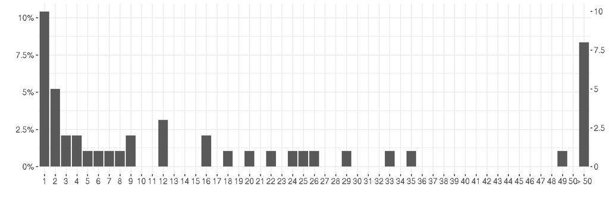

The following graph shows the distribution of R functions by the number of calls.

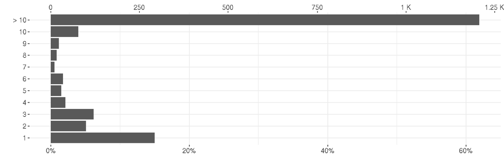

We observe that most functions are called more than 10 times.

## 1.2 Parameters and Arguments

We observed 5 K formal parameter positions. Of the 23.4 M arguments 7.3 M (31.3%) were default arguments and the remaining 16.1 M (68.7%) were non-default arguments. 745.9 K (3%) arguments were missing and 23.4 M were promises.

The following graph shows the distribution of R functions by their formal parameter counts.

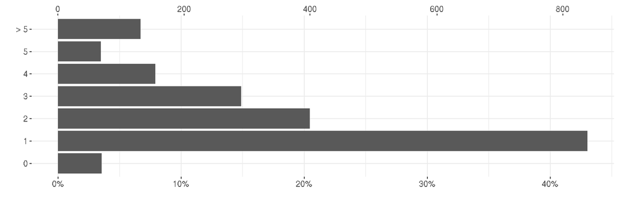

## 1.3 Events and Expressions

902.4 M events were analyzed from 118.7 M expressions. The total event processing rate was 2.6 M events per second. The total expression processing rate was 339.2 K expression evaluations per second.

# 2 Object Counts (Fig. 3)

The following graph shows the distribution of object counts by type.

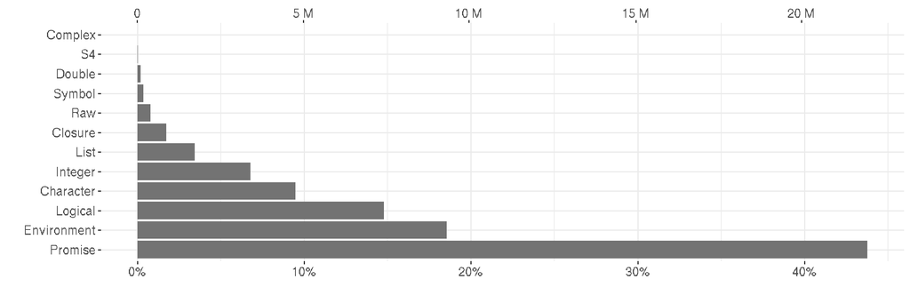

# 3 Promise Result Types (Fig. 4)

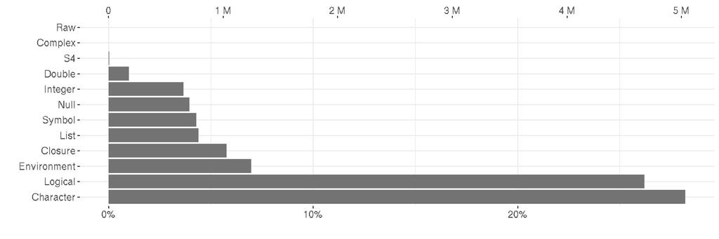

# 4 Promise Expression Types (Fig. 5)

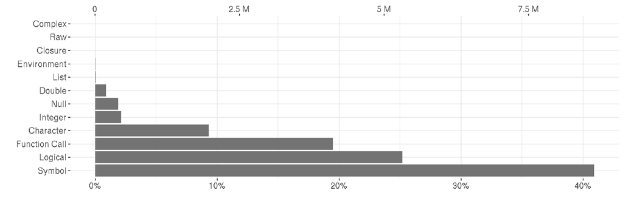

# 5 Function Strictness per package (Fig. 6)

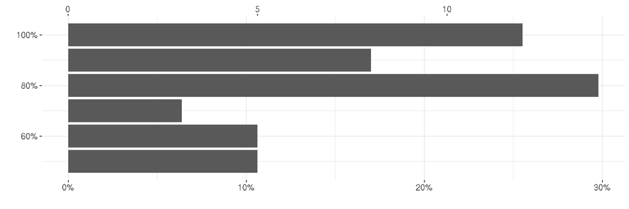

A function is strict if it evaluates all of its arguments. In the corpus, out of a total of 1.6 K non-zero argument functions, 77.1% are strict. Figure above gives a histogram of function strictness ratios per package. The majority of packages mostly contain strict functions. The packages that are less than 75% strict account for only 13 packages (27.7% of all packages) and 428 functions (27.4% of all functions).

# 6 Parameter Strictness (Fig. 7)

The strictness of the 5 K individual parameters positions can also be measured. We distinguish three categories: *Always* is for parameters that are always evaluated, *Never* is for parameters that are never evaluated, and *Sometimes* is for parameters that we have observed being evaluated in some calls and not in others. Figure below illustrates the distribution of parameters across the categories.

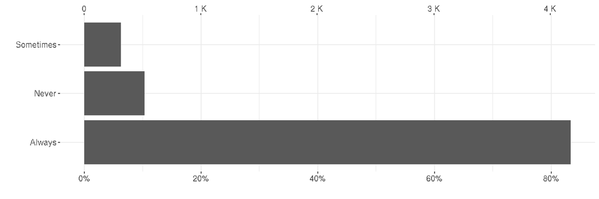

There are 10.3% parameters are never evaluated, and 6.3% parameters are inconsistently evaluated. A strict function has all of its parameters always evaluated.

# 7 Computation Reuse (Fig. 8)

One advantage of call-by-need is that it avoids multiple evaluations of the same expression. How often is this used in practice? Figure below shows, for each individual promise, how often its value was accessed.

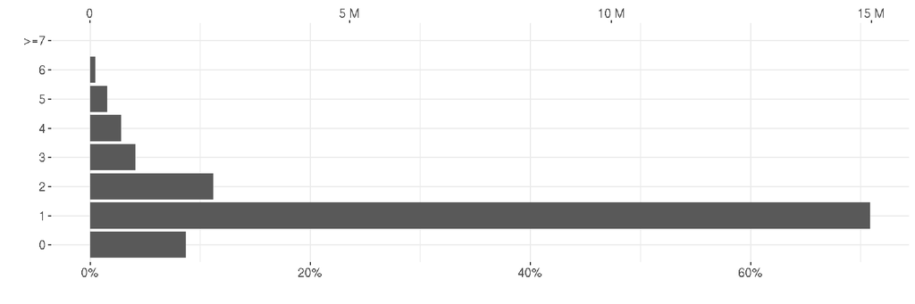

The majority of promises are used once. 11.2% of promises are accessed twice, and 4% are accessed three times. 0% promises are accessed over 1,000 times.

# 8 Promise Evaluation (Fig. 9)

Another advantage of laziness is that could help avoid unnecessary computation. But do programmers avail themselves of this feature? One way to test this hypothesis is to compare the execution time of arguments that are strict (promises passed to *Always* parameters) to those of lazy arguments (promises passed to *Sometimes* parameters) and see if the lazy arguments are more computationally intensive in any way.

Figure below shows the probability density of promises at different running times. Promises running for less than a millisecond are ignored.

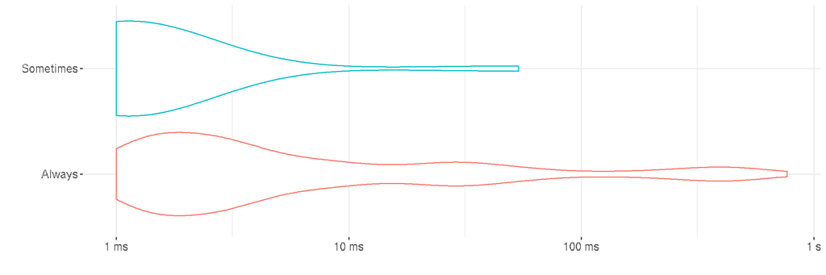

While there is a difference in the profiles, the promises that are passed to Sometimes arguments tend to be faster to evaluate. But given the large amount of promises being observed it is difficult to be conclusive.

# 9 Function Return Type (Fig. 10)

Laziness makes it possible to compute over infinite data structures. While R does not provide any libraries with such data structures, it is conceivable that some programmers may have created some in their code. One can use promises together with environments or closures to create unbounded data. How often does that occur? One thing that we can measure is *escaped promises*, the promises that outlive the function their are passed into.

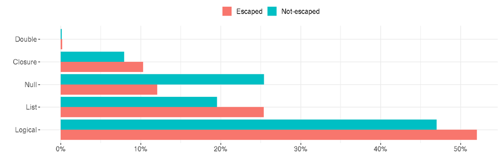

Of the 23.4 M promises we have observed, only 714 escape. This is a rather small number, and we need to establish the reason why the promise escape. One thing we can measure is the return type of the functions for which promises escape.

# 10 Meta-programmed Promises (Fig. 11)

We define meta-programming as the use of the `substitute` function to extract an abstract syntax tree from the body of a promise. Figure below shows the number of promises that were meta-programmed. The graph has four categories: promises that were created but never used, promises that we meta-programmed, promises that we both meta-programmed and accessed, and lastly, promises that were only accessed.

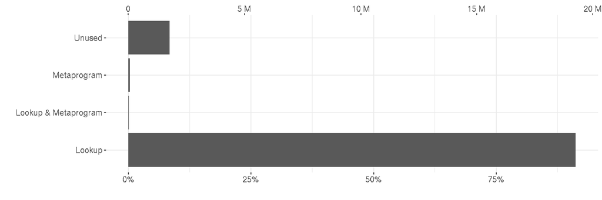

We observed 77.3 K calls (0.9% of all calls) to `substitute` function. The data shows that only 0.3% of promises were used purely for meta-programming purposes, while 0.08% were both forced to obtain a value and used for meta-programming. There are 11 (22.9%) packages that do meta-programming.

# 11 Expression Types of Parameters (Fig. 13)

Figure below shows the contents of expressions held in promises, contrasting promises that are passed to strict (Always) and lazy (Sometimes) argument positions.

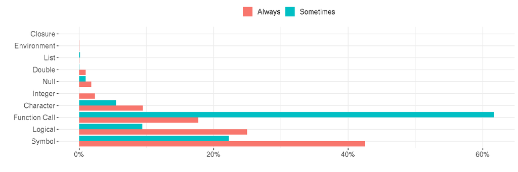

# 12 Function force orders (Fig. 14)

In the graph below, we look at the order in which arguments are forced by functions. We call these force orders.

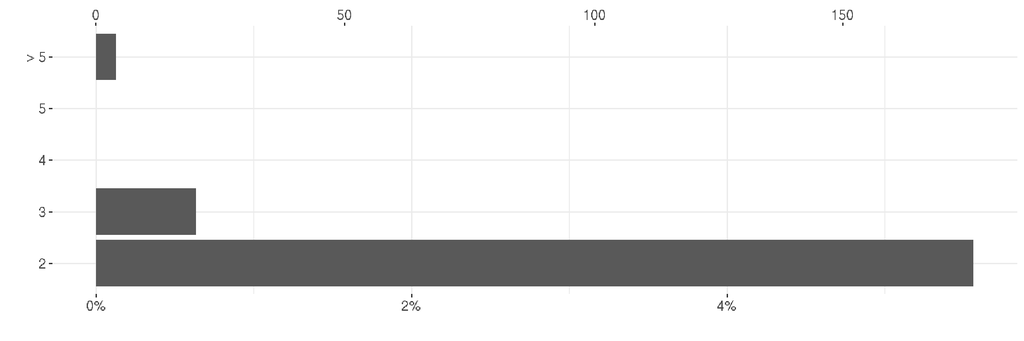

The majority of functions 93.7% have a single force order (regardless of strictness). About 5.6% of the functions have two force order, and very few functions have more than that. This means that for the majority of function we could extract a single force order and simply evaluate the function early. For the multi-force order functions it is reasonable to expect that they are not sensitive to side-effects.